# Project1

Daniel Zinn

2024-12-23

## Reading and processing the data

Reading the given dataset activity.csv

```r
activity_csv<-read.csv('activity.csv')

head(activity_csv)
```

```
##   steps       date interval
## 1    NA 2012-10-01        0
## 2    NA 2012-10-01        5
## 3    NA 2012-10-01       10
## 4    NA 2012-10-01       15
## 5    NA 2012-10-01       20
## 6    NA 2012-10-01       25
```

### 1st plot “Total number of steps per day”

Processing the data by removing NAs, then grouping by the same date, and calculating the sum of the steps for each day.

```r
steps_per_day<- activity_csv %>% filter(!is.na(steps)) %>%
  group_by(date) %>%
  summarize(total_steps=sum(steps))

mean_steps<- mean(steps_per_day$total_steps)
median_steps<- median(steps_per_day$total_steps)

head(steps_per_day)
```

```
## # A tibble: 6 × 2
##   date       total_steps
##   <chr>            <int>
## 1 2012-10-02         126
## 2 2012-10-03       11352
## 3 2012-10-04       12116
## 4 2012-10-05       13294
## 5 2012-10-06       15420
## 6 2012-10-07       11015
```

```r
mean_steps
```

```
## [1] 10766.19
```

```r
median_steps
```

```
## [1] 10765
```

The histogram plot war produced by the base library with the following code:

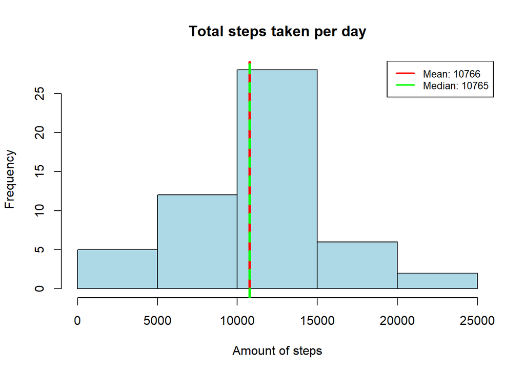

```r
hist(steps_per_day$total_steps,main="Total steps taken per day",
     xlab = "Amount of steps",col = "lightblue")

abline(v=mean_steps,lwd=3, col="red")
abline(v=median_steps,lwd=3,lty=2, col="green")

legend("topright",
       legend=c(paste("Mean:",round(mean_steps,0)),
                paste("Median:",median_steps)),col=c("red","green"),
       lty=1,lwd=2,box.lwd =1,cex=0.8)
```

### Average daily activity pattern

Processing the dataset removing the NAs , grouping by Interval identifier and calculating the average across all days

```r
five_minute<-activity_csv %>%
  filter(!is.na(steps)) %>%
  group_by(interval) %>%
  summarize(average_steps=mean(steps))

head(five_minute)
```

```
## # A tibble: 6 × 2
##   interval average_steps
##      <int>         <dbl>
## 1        0        1.72
## 2        5        0.340
## 3       10        0.132
## 4       15        0.151
## 5       20        0.0755
## 6       25        2.09
```

Plotting using ggplot2 library:

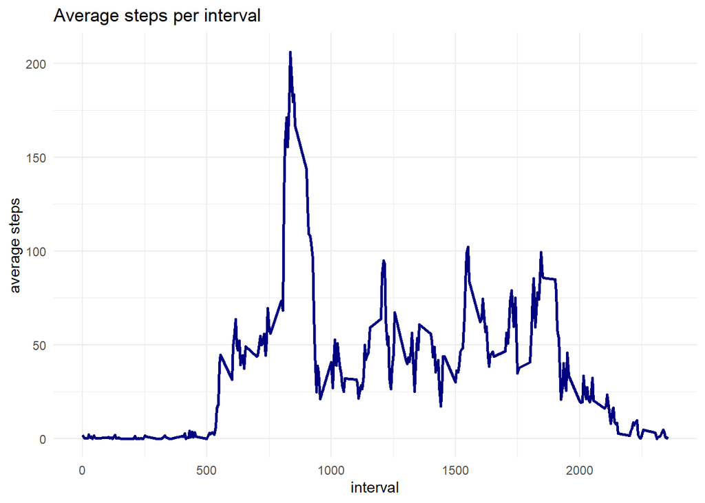

```r
ggplot(data=five_minute,aes(x=interval,y=average_steps))+
  geom_line(color="navy",lwd=1)+
  labs(title="Average steps per interval",
       y="average steps")+
  theme_minimal()
```

## Imputing missing values

for the next plot we are required to impute the missing values.

calculating the amount of rows with NA (because all NAs are in steps column there isnt an Intersection ):

```r
sum(is.na(activity_csv$interval))
```

```
## [1] 0
```

```r
sum(is.na(activity_csv$date))
```

```
## [1] 0
```

```r
sum(is.na(activity_csv$steps))
```

```
## [1] 2304
```

the strategy that we will use is calculating the mean of the steps for the same 5-minute interval and fill the missing data

```r
interval_means<- activity_csv %>% filter(!is.na(steps)) %>%
  group_by(interval) %>% summarize(day_mean=mean(steps))

filled_activity_csv<-activity_csv
for (i in 1:length(filled_activity_csv[,1])) {
  if(is.na(filled_activity_csv[i,1])){
    interval_mean<-interval_means[interval_means$interval==filled_activity_csv[i,3],"day_mean"]
    filled_activity_csv[i,1]<-interval_mean
  }
}
```

We will let the reader compare the values of the first 5 variables

```r
head(interval_means)
```

```
## # A tibble: 6 × 2
##   interval day_mean
##      <int>    <dbl>
## 1        0   1.72
## 2        5   0.340
## 3       10   0.132
## 4       15   0.151
## 5       20   0.0755
## 6       25   2.09
```

```r
head(filled_activity_csv)
```

```
##       steps       date interval
## 1 1.7169811 2012-10-01        0
## 2 0.3396226 2012-10-01        5
## 3 0.1320755 2012-10-01       10
## 4 0.1509434 2012-10-01       15
## 5 0.0754717 2012-10-01       20
## 6 2.0943396 2012-10-01       25
```

creating histogram of total number of stepts taken per day

```r
steps_per_day2<- filled_activity_csv %>% filter(!is.na(steps)) %>%
  group_by(date) %>%
  summarize(total_steps=sum(steps))

mean_steps<- mean(steps_per_day2$total_steps)
median_steps<- median(steps_per_day2$total_steps)

head(steps_per_day)
```

```
## # A tibble: 6 × 2
##   date       total_steps
##   <chr>            <int>
## 1 2012-10-02         126
## 2 2012-10-03       11352
## 3 2012-10-04       12116
## 4 2012-10-05       13294
## 5 2012-10-06       15420
## 6 2012-10-07       11015
```

```r
mean_steps
```

```
## [1] 10766.19
```

```r
median_steps
```

```
## [1] 10766.19
```

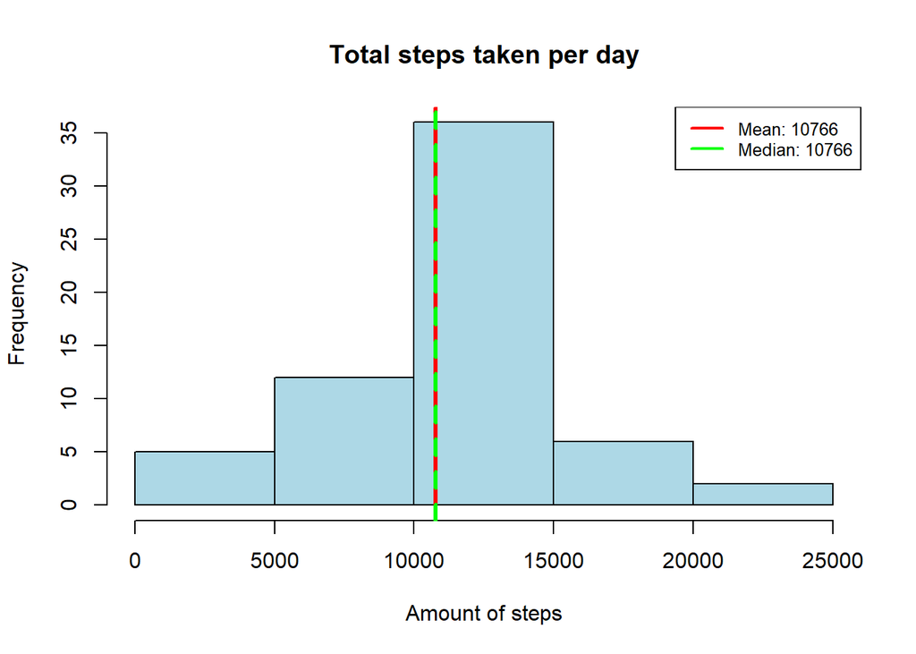

```r
hist(steps_per_day2$total_steps,main="Total steps taken per day",
     xlab = "Amount of steps",col = "lightblue")

abline(v=mean_steps,lwd=3, col="red")
abline(v=median_steps,lwd=3,lty=2, col="green")

legend("topright",
       legend=c(paste("Mean:",round(mean_steps,0)),
                paste("Median:",round(median_steps,0))),col=c("red","green"),
       lty=1,lwd=2,box.lwd =1,cex=0.8)
```

```r
week_days_ends <- filled_activity_csv %>%
  mutate(type = ifelse(weekdays(as.Date(date)) %in% c("Saturday", "Sunday"), "weekend", "weekday"))

week_days_ends<-week_days_ends %>%
  filter(!is.na(steps)) %>%
  group_by(interval, type) %>%
  summarize(average_steps=mean(steps))
head(week_days_ends)
```

```
## # A tibble: 6 × 3
## # Groups:   interval [3]
##   interval type    average_steps
##      <int> <chr>           <dbl>
## 1        0 weekday        2.25
## 2        0 weekend        0.215
## 3        5 weekday        0.445
## 4        5 weekend        0.0425
## 5       10 weekday        0.173
## 6       10 weekend        0.0165
```

plotting the graph

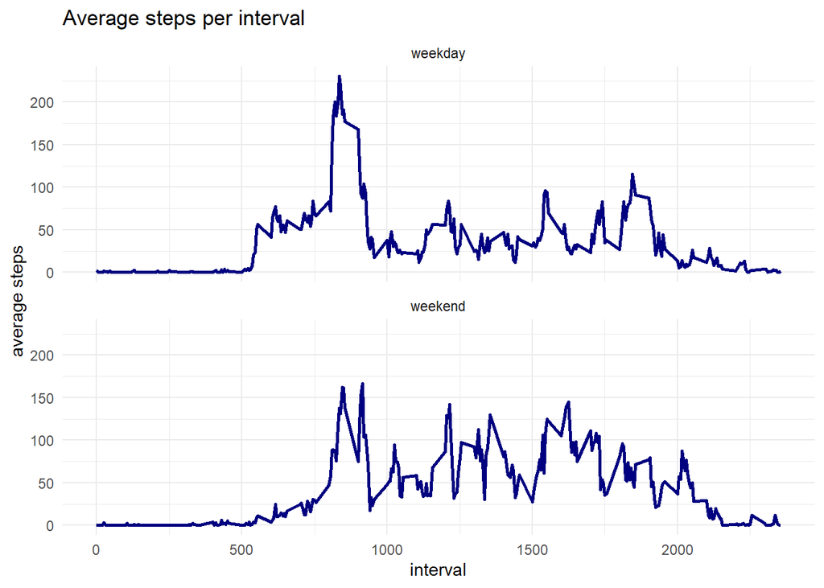

```r
ggplot(data=week_days_ends,aes(x=interval,y=average_steps))+facet_wrap(~type,ncol=1)+
  geom_line(color="navy",lwd=1)+
  labs(title="Average steps per interval",
       y="average steps")+
  theme_minimal()
```